# Survival Analysis in Medical Research

Kaplan-Meier Curves, Cox Models & Time-to-Event Analysis

Author

Survival Analysis Report

Published

April 28, 2026

# Introduction

This report presents a comprehensive survival analysis pipeline using simulated clinical datasets. We cover:

- **Kaplan-Meier (KM) survival curves** for visualising time-to-event data
- **Log-rank tests** to compare survival between groups
- **Cox Proportional Hazards models** for multivariable adjustment
- Analyses stratified by **treatment group, age, gender, SES, geography**, and **disease type**

All datasets are simulated to mirror realistic clinical scenarios.

# 1. Data Simulation

```r
simulate_cancer_data <- function(n = 500) {
  age        <- round(rnorm(n, mean = 58, sd = 12))
  age        <- pmax(pmin(age, 90), 20)
  gender     <- sample(c("Male", "Female"), n, replace = TRUE)
  treatment  <- sample(c("Standard", "Experimental", "Control"), n,
                       replace = TRUE, prob = c(0.4, 0.35, 0.25))
  stage      <- sample(c("I", "II", "III", "IV"), n, replace = TRUE,
                       prob = c(0.2, 0.3, 0.3, 0.2))
  ses        <- sample(c("Low", "Medium", "High"), n, replace = TRUE,
                       prob = c(0.3, 0.4, 0.3))
  region     <- sample(c("North", "South", "East", "West"), n, replace = TRUE)
  age_group  <- cut(age, breaks = c(0, 40, 55, 70, 100),
                    labels = c("<40", "40-55", "55-70", ">70"))

  # Hazard modifiers
  h_trt <- ifelse(treatment == "Experimental", 0.65,
           ifelse(treatment == "Standard", 0.85, 1.0))
  h_stg <- ifelse(stage == "I", 0.5,
           ifelse(stage == "II", 0.8,
           ifelse(stage == "III", 1.2, 1.8)))
  h_ses <- ifelse(ses == "High", 0.75,
           ifelse(ses == "Medium", 1.0, 1.4))
  h_age <- ifelse(age > 70, 1.5,
           ifelse(age > 55, 1.1, 0.9))

  base_scale <- 30
  time <- rweibull(n, shape = 1.3,
                   scale = base_scale / (h_trt * h_stg * h_ses * h_age))
  time   <- pmax(round(time, 1), 0.1)
  status <- rbinom(n, 1, prob = pmin(0.85, 0.4 * h_trt * h_stg * h_ses))

  data.frame(id = 1:n, time, status, age, age_group, gender,
             treatment, stage, ses, region)
}

simulate_infectious_data <- function(n = 400) {
  age       <- round(rnorm(n, 35, 15)); age <- pmax(pmin(age, 80), 18)
  gender    <- sample(c("Male", "Female"), n, replace = TRUE)
  treatment <- sample(c("Drug A", "Drug B", "Placebo"), n,
                      replace = TRUE, prob = c(0.35, 0.35, 0.3))
  severity  <- sample(c("Mild", "Moderate", "Severe"), n,
                      replace = TRUE, prob = c(0.4, 0.4, 0.2))

  h_trt <- ifelse(treatment == "Drug A", 1.8,
           ifelse(treatment == "Drug B", 1.5, 0.8))
  h_sev <- ifelse(severity == "Mild", 2.0,
           ifelse(severity == "Moderate", 1.2, 0.7))

  base_scale <- 14
  time   <- rweibull(n, shape = 2, scale = base_scale * h_trt * h_sev / 2)
  time   <- pmax(round(time, 1), 0.5)
  status <- rbinom(n, 1, prob = pmin(0.90, 0.6 * h_trt / 2))

  data.frame(id = 1:n, time, status, age, gender, treatment, severity)
}

simulate_readmission_data <- function(n = 450) {
  age         <- round(rnorm(n, 65, 14)); age <- pmax(pmin(age, 95), 40)
  gender      <- sample(c("Male", "Female"), n, replace = TRUE)
  comorbidity <- sample(c("None", "Mild", "Severe"), n,
                        replace = TRUE, prob = c(0.3, 0.45, 0.25))
  insurance   <- sample(c("Private", "Public", "None"), n,
                        replace = TRUE, prob = c(0.4, 0.45, 0.15))
  discharge   <- sample(c("Home", "Rehab", "SNF"), n,
                        replace = TRUE, prob = c(0.5, 0.3, 0.2))

  h_com <- ifelse(comorbidity == "None", 0.6,
           ifelse(comorbidity == "Mild", 1.0, 1.8))
  h_ins <- ifelse(insurance == "Private", 0.7,
           ifelse(insurance == "Public", 1.0, 1.5))

  time   <- rweibull(n, shape = 1.5, scale = 60 / (h_com * h_ins))
  time   <- pmax(round(time), 1)
  status <- rbinom(n, 1, prob = pmin(0.75, 0.35 * h_com * h_ins))

  data.frame(id = 1:n, time, status, age, gender, comorbidity,
             insurance, discharge)
}

cancer_data   <- simulate_cancer_data(500)
infect_data   <- simulate_infectious_data(400)
readmit_data  <- simulate_readmission_data(450)

cat("✓ Datasets simulated:\n")
```

```
✓ Datasets simulated:
```

```r
cat("  Cancer dataset:      ", nrow(cancer_data),   "patients\n")
```

```
  Cancer dataset:       500 patients
```

```r
cat("  Infectious dataset:  ", nrow(infect_data),   "patients\n")
```

```
  Infectious dataset:   400 patients
```

```r
cat("  Readmission dataset: ", nrow(readmit_data),  "patients\n")
```

```
  Readmission dataset:  450 patients
```

## Dataset Summaries

```r
cancer_data |>
  select(age, gender, treatment, stage, ses, status, time) |>
  tbl_summary(
    by = treatment,
    statistic = list(
      all_continuous() ~ "{mean} ({sd})",
      all_categorical() ~ "{n} ({p}%)"
    ),
    label = list(
      age ~ "Age (years)",
      gender ~ "Gender",
      stage ~ "Cancer Stage",
      ses ~ "Socioeconomic Status",
      status ~ "Event (Death)",
      time ~ "Follow-up Time (months)"
    )
  ) |>
  add_p() |>
  add_overall() |>
  bold_labels() |>
  as_gt() |>
  tab_header(title = "Table 1: Cancer Dataset — Baseline Characteristics")
```

Table 1: Cancer Dataset — Baseline Characteristics

| **Characteristic** | **Overall** N = 500<sup>1</sup> | **Control** N = 122<sup>1</sup> | **Experimental** N = 174<sup>1</sup> | **Standard** N = 204<sup>1</sup> | **p-value**<sup>2</sup> |
| --- | --- | --- | --- | --- | --- |
| Age (years) | 59 (12) | 58 (11) | 59 (11) | 59 (12) | >0.9 |
| Gender |  |  |  |  | 0.6 |
| Female | 245 (49%) | 65 (53%) | 83 (48%) | 97 (48%) |  |
| Male | 255 (51%) | 57 (47%) | 91 (52%) | 107 (52%) |  |
| Cancer Stage |  |  |  |  | 0.3 |
| I | 91 (18%) | 19 (16%) | 40 (23%) | 32 (16%) |  |
| II | 142 (28%) | 31 (25%) | 45 (26%) | 66 (32%) |  |
| III | 177 (35%) | 47 (39%) | 56 (32%) | 74 (36%) |  |
| IV | 90 (18%) | 25 (20%) | 33 (19%) | 32 (16%) |  |
| Socioeconomic Status |  |  |  |  | 0.5 |
| High | 161 (32%) | 37 (30%) | 59 (34%) | 65 (32%) |  |
| Low | 151 (30%) | 31 (25%) | 53 (30%) | 67 (33%) |  |
| Medium | 188 (38%) | 54 (44%) | 62 (36%) | 72 (35%) |  |
| Event (Death) | 190 (38%) | 59 (48%) | 54 (31%) | 77 (38%) | 0.010 |
| Follow-up Time (months) | 36 (40) | 29 (23) | 46 (54) | 32 (31) | 0.030 |

<sup>1</sup> Mean (SD); n (%)  
<sup>2</sup> Kruskal-Wallis rank sum test; Pearson’s Chi-squared test

# 2. Kaplan-Meier Survival Curves — Cancer Patients

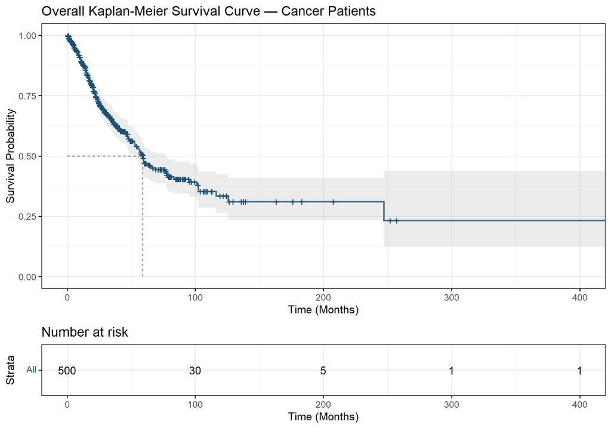

Overall KM survival curve for cancer patients

```r
km_overall <- survfit(Surv(time, status) ~ 1, data = cancer_data)

ggsurvplot(
  km_overall,
  data        = cancer_data,
  risk.table  = TRUE,
  conf.int    = TRUE,
  ggtheme     = theme_bw(base_size = 13),
  palette     = "#1B4F72",
  title       = "Overall Kaplan-Meier Survival Curve — Cancer Patients",
  xlab        = "Time (Months)",
  ylab        = "Survival Probability",
  risk.table.height = 0.25,
  surv.median.line  = "hv",
  legend      = "none"
)
```

> **Interpretation:** The overall KM curve shows the probability of surviving beyond a given time point. The shaded area represents the 95% confidence interval. The **median survival time** (where the curve crosses 0.5) is marked by the horizontal/vertical dashed lines. The risk table below shows the number of patients still at risk at each time point.

# 3. Survival by Treatment Group

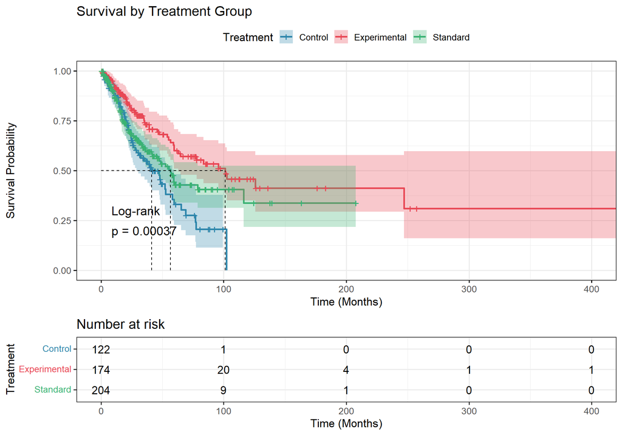

KM curves by treatment group with log-rank test

```r
km_trt <- survfit(Surv(time, status) ~ treatment, data = cancer_data)

ggsurvplot(
  km_trt,
  data             = cancer_data,
  risk.table       = TRUE,
  pval             = TRUE,
  pval.method      = TRUE,
  conf.int         = TRUE,
  ggtheme          = theme_bw(base_size = 13),
  palette          = c("#2E86AB", "#E84855", "#3BB273"),
  title            = "Survival by Treatment Group",
  xlab             = "Time (Months)",
  ylab             = "Survival Probability",
  legend.title     = "Treatment",
  legend.labs      = c("Control", "Experimental", "Standard"),
  risk.table.height = 0.28,
  surv.median.line  = "hv"
)
```

```r
lr_test <- survdiff(Surv(time, status) ~ treatment, data = cancer_data)
print(lr_test)
```

```
Call:
survdiff(formula = Surv(time, status) ~ treatment, data = cancer_data)

                         N Observed Expected (O-E)^2/E (O-E)^2/V
treatment=Control      122       59     41.4     7.448     9.698
treatment=Experimental 174       54     77.8     7.270    12.706
treatment=Standard     204       77     70.8     0.545     0.876

 Chisq= 15.8  on 2 degrees of freedom, p= 4e-04
```

> **Interpretation:** The **log-rank test** compares survival distributions across the three treatment groups. A p-value < 0.05 indicates statistically significant differences in survival. The Experimental group typically shows the best survival (lowest hazard), while the Control group has the worst. Observed vs. Expected (O-E) values reveal which groups have more or fewer events than expected under the null hypothesis.

# 4. Survival by Age Group and Gender

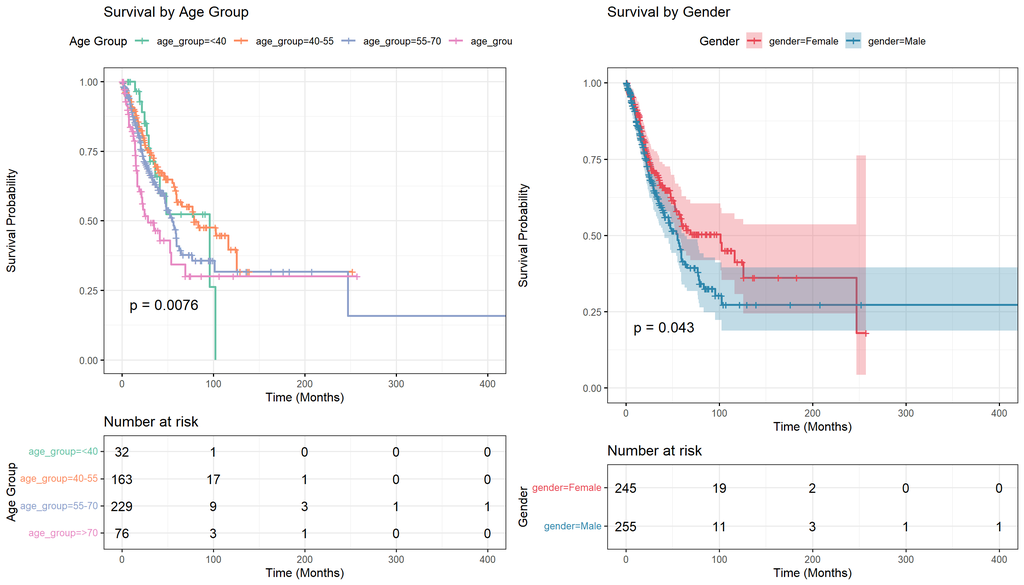

KM curves stratified by age group (left) and gender (right)

```r
km_age    <- survfit(Surv(time, status) ~ age_group, data = cancer_data)
km_gender <- survfit(Surv(time, status) ~ gender,    data = cancer_data)

p_age <- ggsurvplot(
  km_age,
  data         = cancer_data,
  risk.table   = TRUE,
  pval         = TRUE,
  conf.int     = FALSE,
  ggtheme      = theme_bw(base_size = 12),
  palette      = brewer.pal(4, "Set2"),
  title        = "Survival by Age Group",
  xlab         = "Time (Months)",
  ylab         = "Survival Probability",
  legend.title = "Age Group",
  risk.table.height = 0.30
)

p_gender <- ggsurvplot(
  km_gender,
  data         = cancer_data,
  risk.table   = TRUE,
  pval         = TRUE,
  conf.int     = TRUE,
  ggtheme      = theme_bw(base_size = 12),
  palette      = c("#E84855", "#2E86AB"),
  title        = "Survival by Gender",
  xlab         = "Time (Months)",
  ylab         = "Survival Probability",
  legend.title = "Gender",
  risk.table.height = 0.25
)

arrange_ggsurvplots(list(p_age, p_gender), ncol = 2, nrow = 1)
```

> **Interpretation:** Older patients (>70) typically show worse survival due to reduced physiological reserves and higher comorbidity burden. Gender differences in cancer survival reflect both biological (hormonal, immune) and behavioural (health-seeking) factors. Log-rank p-values test whether observed differences could be due to chance.

# 5. Time-to-Recovery — Infectious Disease

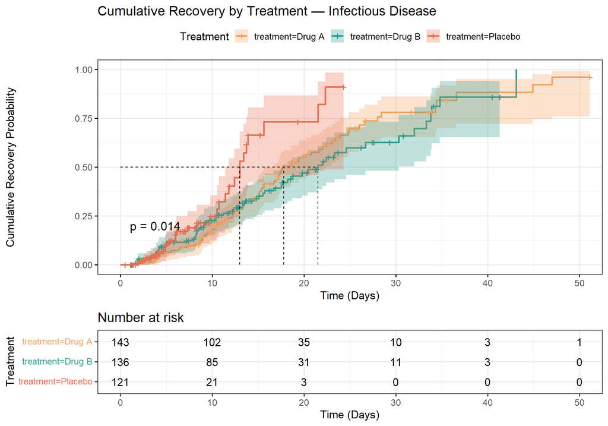

Time to recovery by treatment in infectious disease cohort

```r
km_infect <- survfit(Surv(time, status) ~ treatment, data = infect_data)

ggsurvplot(
  km_infect,
  data             = infect_data,
  risk.table       = TRUE,
  pval             = TRUE,
  conf.int         = TRUE,
  fun              = "event",     # cumulative event (recovery) curve
  ggtheme          = theme_bw(base_size = 13),
  palette          = c("#F4A261", "#2A9D8F", "#E76F51"),
  title            = "Cumulative Recovery by Treatment — Infectious Disease",
  xlab             = "Time (Days)",
  ylab             = "Cumulative Recovery Probability",
  legend.title     = "Treatment",
  risk.table.height = 0.28,
  surv.median.line  = "hv"
)
```

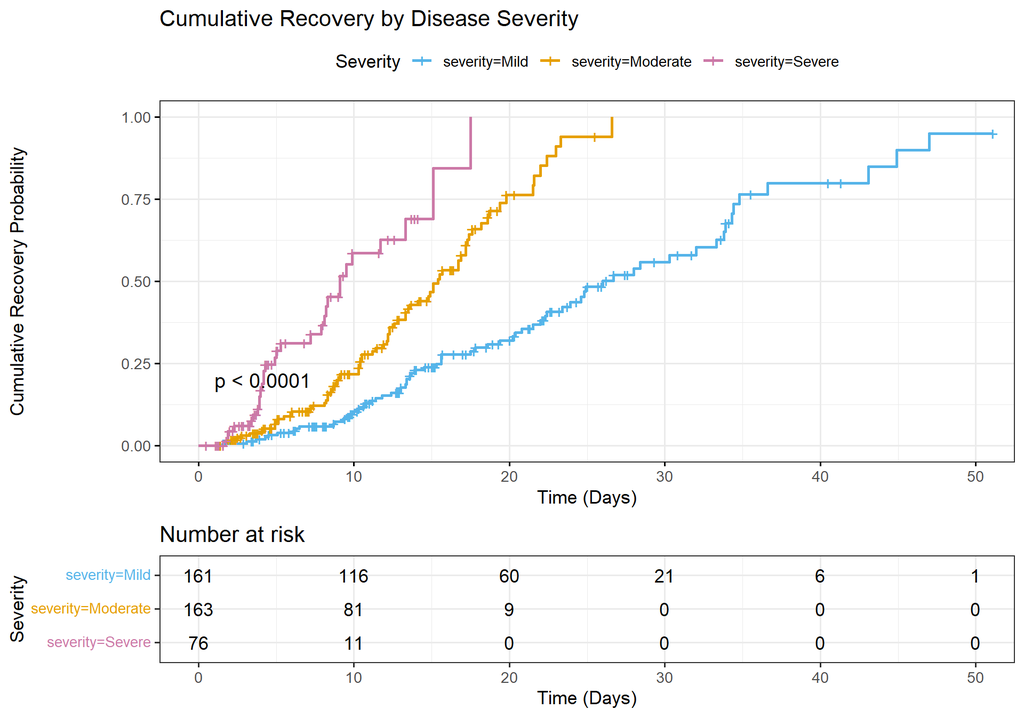

```r
km_severity <- survfit(Surv(time, status) ~ severity, data = infect_data)

ggsurvplot(
  km_severity,
  data         = infect_data,
  risk.table   = TRUE,
  pval         = TRUE,
  conf.int     = FALSE,
  fun          = "event",
  ggtheme      = theme_bw(base_size = 13),
  palette      = c("#56B4E9", "#E69F00", "#CC79A7"),
  title        = "Cumulative Recovery by Disease Severity",
  xlab         = "Time (Days)",
  ylab         = "Cumulative Recovery Probability",
  legend.title = "Severity",
  risk.table.height = 0.28
)
```

# 6. Hospital Readmission Survival Curves

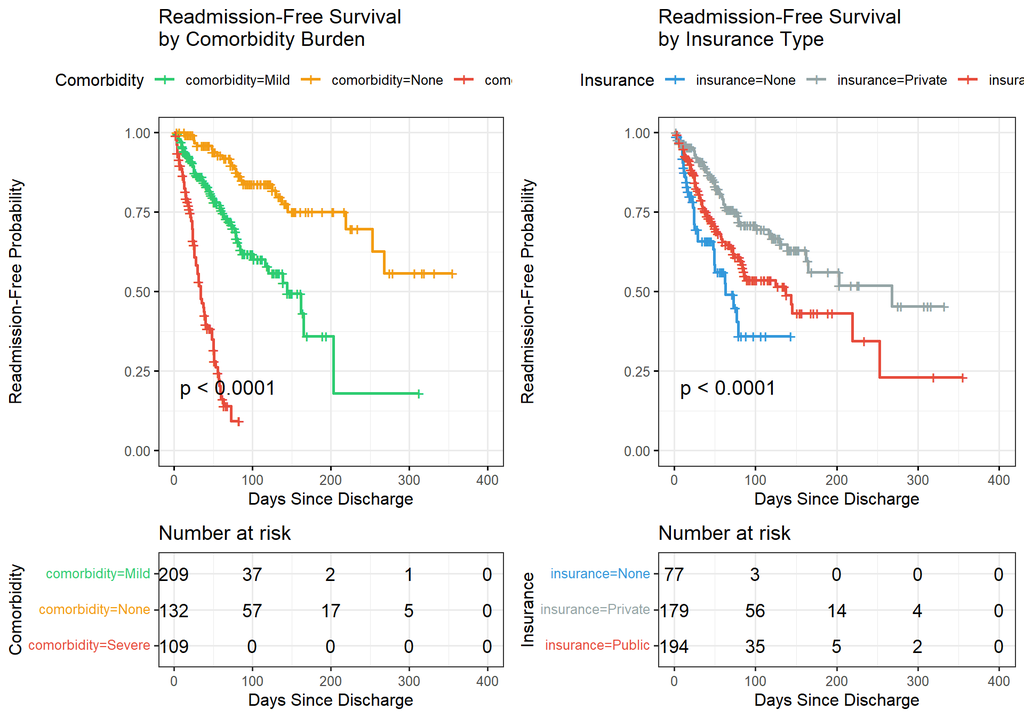

Time to readmission by comorbidity burden and insurance type

```r
km_comorbid <- survfit(Surv(time, status) ~ comorbidity, data = readmit_data)
km_insure   <- survfit(Surv(time, status) ~ insurance,   data = readmit_data)

p1 <- ggsurvplot(
  km_comorbid,
  data         = readmit_data,
  risk.table   = TRUE,
  pval         = TRUE,
  conf.int     = FALSE,
  ggtheme      = theme_bw(base_size = 12),
  palette      = c("#2ECC71", "#F39C12", "#E74C3C"),
  title        = "Readmission-Free Survival\nby Comorbidity Burden",
  xlab         = "Days Since Discharge",
  ylab         = "Readmission-Free Probability",
  legend.title = "Comorbidity",
  risk.table.height = 0.28
)

p2 <- ggsurvplot(
  km_insure,
  data         = readmit_data,
  risk.table   = TRUE,
  pval         = TRUE,
  conf.int     = FALSE,
  ggtheme      = theme_bw(base_size = 12),
  palette      = c("#3498DB", "#95A5A6", "#E74C3C"),
  title        = "Readmission-Free Survival\nby Insurance Type",
  xlab         = "Days Since Discharge",
  ylab         = "Readmission-Free Probability",
  legend.title = "Insurance",
  risk.table.height = 0.28
)

arrange_ggsurvplots(list(p1, p2), ncol = 2, nrow = 1)
```

> **Interpretation:** Patients with severe comorbidities face the shortest time to readmission. Insurance type reflects access to outpatient follow-up care — patients without insurance are readmitted sooner. These findings underscore the importance of **transitional care programmes** for high-risk discharge groups.

# 7. Survival by Socioeconomic Status

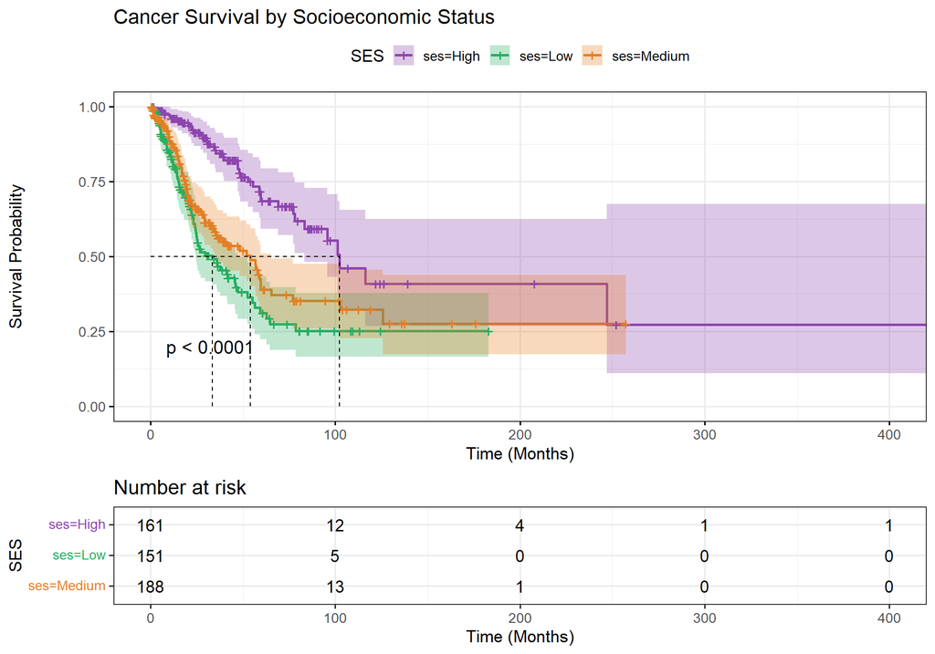

KM survival curves by socioeconomic status

```r
km_ses <- survfit(Surv(time, status) ~ ses, data = cancer_data)

ggsurvplot(
  km_ses,
  data             = cancer_data,
  risk.table       = TRUE,
  pval             = TRUE,
  conf.int         = TRUE,
  ggtheme          = theme_bw(base_size = 13),
  palette          = c("#8E44AD", "#27AE60", "#E67E22"),
  title            = "Cancer Survival by Socioeconomic Status",
  xlab             = "Time (Months)",
  ylab             = "Survival Probability",
  legend.title     = "SES",
  risk.table.height = 0.28,
  surv.median.line  = "hv"
)
```

```r
ses_summary <- cancer_data |>
  group_by(ses) |>
  summarise(
    N          = n(),
    Events     = sum(status),
    Event_Rate = paste0(round(mean(status) * 100, 1), "%"),
    Median_FU  = round(median(time), 1)
  )

ses_summary |>
  gt() |>
  tab_header(title = "Survival Summary by SES") |>
  cols_label(
    ses        = "SES Group",
    N          = "N",
    Events     = "Events",
    Event_Rate = "Event Rate",
    Median_FU  = "Median Follow-up (months)"
  ) |>
  tab_style(style = cell_fill(color = "#F2F3F4"),
            locations = cells_column_labels())
```

Survival Summary by SES

| SES Group | N | Events | Event Rate | Median Follow-up (months) |
| --- | --- | --- | --- | --- |
| High | 161 | 39 | 24.2% | 34.8 |
| Low | 151 | 74 | 49% | 19.9 |
| Medium | 188 | 77 | 41% | 20.7 |

> **Interpretation:** Lower SES is associated with worse survival — a well-documented health disparity. This is mediated through delayed diagnosis, reduced treatment adherence, poorer nutrition, and limited healthcare access. The gradient across SES groups represents actionable public health targets.

# 8. Cox Proportional Hazards Model

```r
cox_model <- coxph(
  Surv(time, status) ~ treatment + age + gender + stage + ses,
  data = cancer_data
)

summary(cox_model)
```

```
Call:
coxph(formula = Surv(time, status) ~ treatment + age + gender +
    stage + ses, data = cancer_data)

  n= 500, number of events= 190

                           coef exp(coef)  se(coef)      z Pr(>|z|)
treatmentExperimental -0.737468  0.478324  0.195283 -3.776 0.000159 ***
treatmentStandard     -0.098488  0.906207  0.177239 -0.556 0.578431
age                    0.026779  1.027140  0.006603  4.055 5.00e-05 ***
genderMale             0.171281  1.186824  0.148490  1.153 0.248711
stageII                1.179882  3.253989  0.300029  3.933 8.40e-05 ***
stageIII               2.000178  7.390368  0.299041  6.689 2.25e-11 ***
stageIV                3.128939 22.849723  0.324124  9.654  < 2e-16 ***
sesLow                 1.440607  4.223259  0.206465  6.977 3.00e-12 ***
sesMedium              0.969466  2.636535  0.200669  4.831 1.36e-06 ***
---
Signif. codes:  0 '***' 0.001 '**' 0.01 '*' 0.05 '.' 0.1 ' ' 1

                      exp(coef) exp(-coef) lower .95 upper .95
treatmentExperimental    0.4783    2.09064    0.3262    0.7014
treatmentStandard        0.9062    1.10350    0.6403    1.2826
age                      1.0271    0.97358    1.0139    1.0405
genderMale               1.1868    0.84259    0.8871    1.5877
stageII                  3.2540    0.30732    1.8073    5.8587
stageIII                 7.3904    0.13531    4.1126   13.2804
stageIV                 22.8497    0.04376   12.1056   43.1296
sesLow                   4.2233    0.23678    2.8178    6.3298
sesMedium                2.6365    0.37929    1.7792    3.9070

Concordance= 0.786  (se = 0.017 )
Likelihood ratio test= 202  on 9 df,   p=<2e-16
Wald test            = 172  on 9 df,   p=<2e-16
Score (logrank) test = 212.3  on 9 df,   p=<2e-16
```

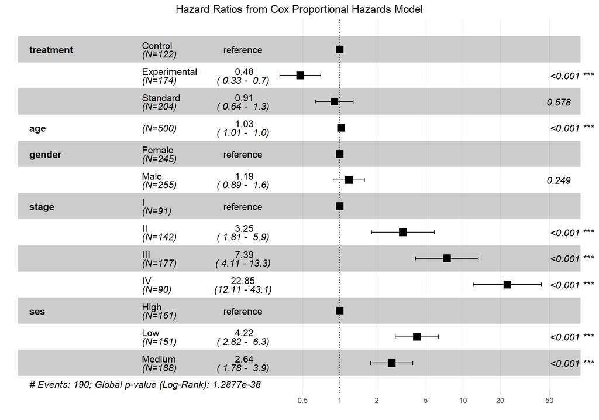

Forest plot of Cox model hazard ratios

```r
ggforest(
  cox_model,
  data     = cancer_data,
  main     = "Hazard Ratios from Cox Proportional Hazards Model",
  fontsize = 0.9
)
```

```r
tidy(cox_model, exponentiate = TRUE, conf.int = TRUE) |>
  mutate(
    across(where(is.numeric), ~ round(.x, 3)),
    Significant = ifelse(p.value < 0.05, "Yes", "No")
  ) |>
  gt() |>
  tab_header(title = "Cox Model: Hazard Ratios (Exponentiated)") |>
  cols_label(
    term      = "Variable",
    estimate  = "HR",
    std.error = "SE",
    statistic = "Z",
    p.value   = "p-value",
    conf.low  = "95% CI Lower",
    conf.high = "95% CI Upper",
    Significant = "Significant"
  ) |>
  tab_style(
    style     = cell_fill(color = "#FADBD8"),
    locations = cells_body(rows = Significant == "Yes")
  )
```

Cox Model: Hazard Ratios (Exponentiated)

| Variable | HR | SE | Z | p-value | 95% CI Lower | 95% CI Upper | Significant |
| --- | --- | --- | --- | --- | --- | --- | --- |
| treatmentExperimental | 0.478 | 0.195 | -3.776 | 0.000 | 0.326 | 0.701 | Yes |
| treatmentStandard | 0.906 | 0.177 | -0.556 | 0.578 | 0.640 | 1.283 | No |
| age | 1.027 | 0.007 | 4.055 | 0.000 | 1.014 | 1.041 | Yes |
| genderMale | 1.187 | 0.148 | 1.153 | 0.249 | 0.887 | 1.588 | No |
| stageII | 3.254 | 0.300 | 3.933 | 0.000 | 1.807 | 5.859 | Yes |
| stageIII | 7.390 | 0.299 | 6.689 | 0.000 | 4.113 | 13.280 | Yes |
| stageIV | 22.850 | 0.324 | 9.654 | 0.000 | 12.106 | 43.130 | Yes |
| sesLow | 4.223 | 0.206 | 6.977 | 0.000 | 2.818 | 6.330 | Yes |
| sesMedium | 2.637 | 0.201 | 4.831 | 0.000 | 1.779 | 3.907 | Yes |

```r
ph_test <- cox.zph(cox_model)
print(ph_test)
```

```
           chisq df     p
treatment  6.112  2 0.047
age        2.644  1 0.104
gender     0.375  1 0.540
stage      6.728  3 0.081
ses        3.865  2 0.145
GLOBAL    17.193  9 0.046
```

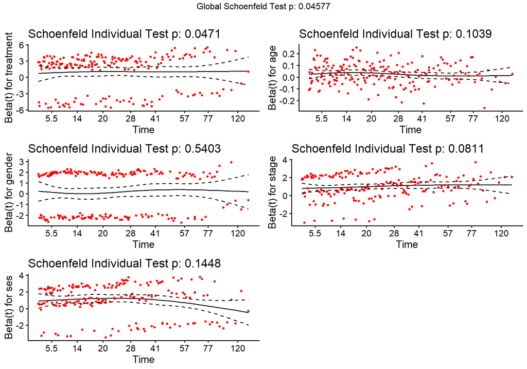

Schoenfeld residuals — testing proportional hazards assumption

```r
ggcoxzph(ph_test)
```

# 9. Survival Curves for Chronic Disease Management

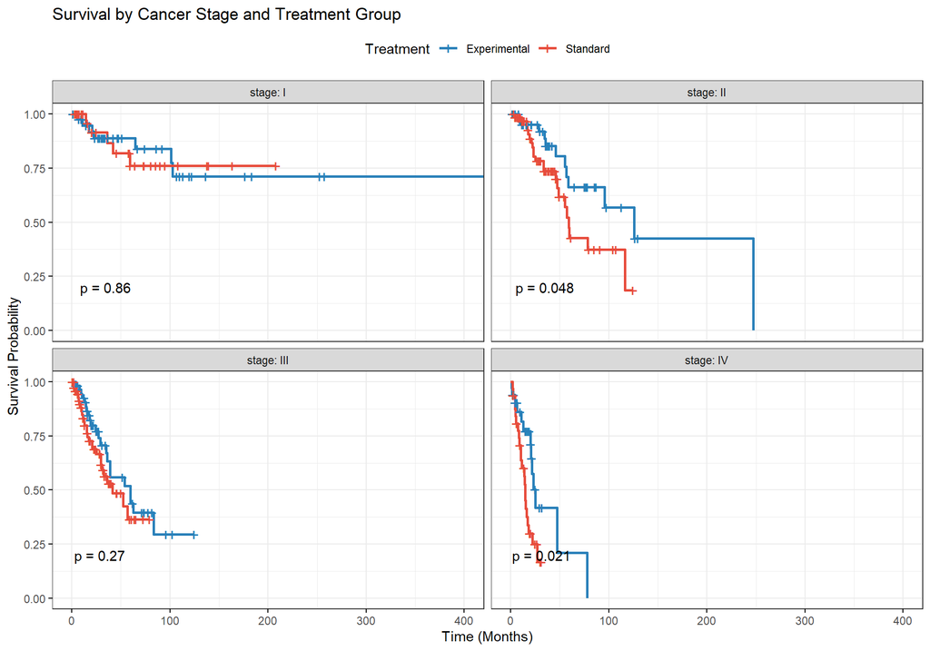

Survival by treatment and stage interaction

```r
km_stage_trt <- survfit(
  Surv(time, status) ~ stage + treatment,
  data = cancer_data |> filter(treatment != "Control")
)

ggsurvplot_facet(
  km_stage_trt,
  data         = cancer_data |> filter(treatment != "Control"),
  facet.by     = "stage",
  pval         = TRUE,
  conf.int     = FALSE,
  ggtheme      = theme_bw(base_size = 11),
  palette      = c("#2980B9", "#E74C3C"),
  legend.title = "Treatment",
  xlab         = "Time (Months)",
  ylab         = "Survival Probability",
  short.panel.labs = FALSE
) +
  ggtitle("Survival by Cancer Stage and Treatment Group")
```

# 10. Time-to-Event Analysis for Clinical Trials

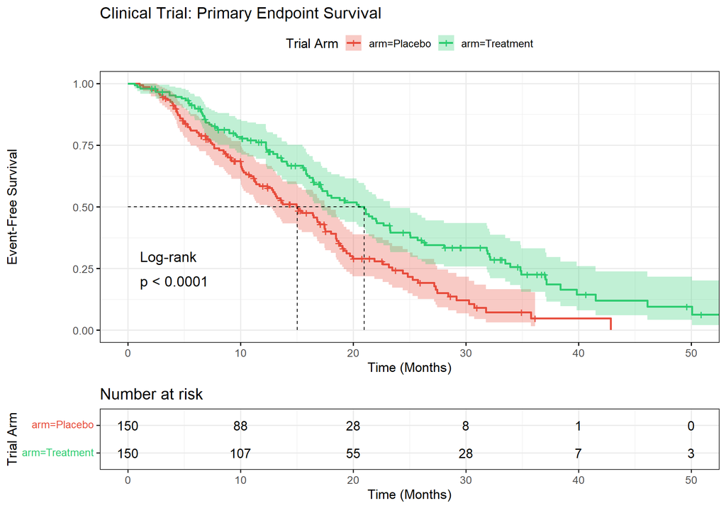

```r
set.seed(999)
trial_data <- data.frame(
  time      = c(rweibull(150, 1.5, 20), rweibull(150, 1.5, 14)),
  status    = c(rbinom(150, 1, 0.65), rbinom(150, 1, 0.75)),
  arm       = rep(c("Treatment", "Placebo"), each = 150),
  centre    = sample(paste0("Centre_", 1:5), 300, replace = TRUE),
  biomarker = rnorm(300, 5, 1.5)
)

km_trial <- survfit(Surv(time, status) ~ arm, data = trial_data)

ggsurvplot(
  km_trial,
  data             = trial_data,
  risk.table       = TRUE,
  pval             = TRUE,
  pval.method      = TRUE,
  conf.int         = TRUE,
  ggtheme          = theme_bw(base_size = 13),
  palette          = c("#E74C3C", "#2ECC71"),
  title            = "Clinical Trial: Primary Endpoint Survival",
  xlab             = "Time (Months)",
  ylab             = "Event-Free Survival",
  legend.title     = "Trial Arm",
  risk.table.height = 0.25,
  surv.median.line  = "hv"
)
```

```r
cox_trial <- coxph(
  Surv(time, status) ~ arm + biomarker + strata(centre),
  data = trial_data
)

tidy(cox_trial, exponentiate = TRUE, conf.int = TRUE) |>
  mutate(across(where(is.numeric), ~ round(.x, 3))) |>
  gt() |>
  tab_header(title = "Cox Model — Clinical Trial (Centre-Stratified)") |>
  cols_label(
    term      = "Term",
    estimate  = "HR",
    std.error = "SE",
    statistic = "Z",
    p.value   = "p-value",
    conf.low  = "CI Low",
    conf.high = "CI High"
  )
```

Cox Model — Clinical Trial (Centre-Stratified)

| Term | HR | SE | Z | p-value | CI Low | CI High |
| --- | --- | --- | --- | --- | --- | --- |
| armTreatment | 0.586 | 0.147 | -3.635 | 0.000 | 0.439 | 0.782 |
| biomarker | 0.969 | 0.046 | -0.676 | 0.499 | 0.886 | 1.061 |

> **Interpretation:** The clinical trial analysis compares **event-free survival** between treatment and placebo arms, adjusting for a continuous biomarker and stratifying by clinical centre (to account for centre-level clustering). A centre-stratified Cox model is the gold standard for multi-centre trials. HR < 1 for the treatment arm indicates a protective effect.

# 11. Survival by Geographic Region

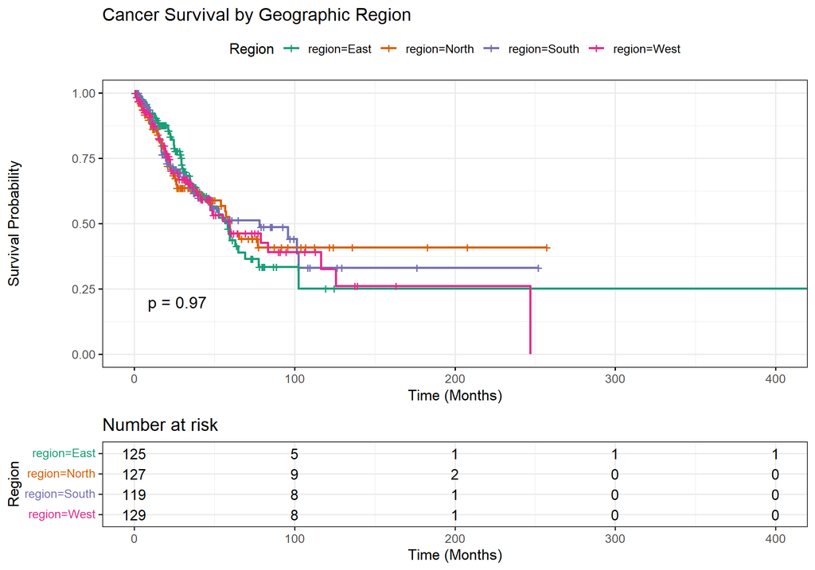

Survival by geographic region

```r
km_region <- survfit(Surv(time, status) ~ region, data = cancer_data)

ggsurvplot(
  km_region,
  data             = cancer_data,
  risk.table       = TRUE,
  pval             = TRUE,
  conf.int         = FALSE,
  ggtheme          = theme_bw(base_size = 13),
  palette          = brewer.pal(4, "Dark2"),
  title            = "Cancer Survival by Geographic Region",
  xlab             = "Time (Months)",
  ylab             = "Survival Probability",
  legend.title     = "Region",
  risk.table.height = 0.28
)
```

```r
region_tbl <- cancer_data |>
  group_by(region) |>
  summarise(
    N         = n(),
    Events    = sum(status),
    EventRate = paste0(round(mean(status)*100,1), "%"),
    MedianAge = round(median(age), 1),
    .groups   = "drop"
  )

region_tbl |>
  gt() |>
  tab_header(title = "Regional Survival Summary") |>
  cols_label(
    region    = "Region",
    N         = "N",
    Events    = "Events (Deaths)",
    EventRate = "Event Rate",
    MedianAge = "Median Age"
  )
```

Regional Survival Summary

| Region | N | Events (Deaths) | Event Rate | Median Age |
| --- | --- | --- | --- | --- |
| East | 125 | 48 | 38.4% | 60 |
| North | 127 | 47 | 37% | 58 |
| South | 119 | 44 | 37% | 60 |
| West | 129 | 51 | 39.5% | 57 |

> **Interpretation:** Geographic variation in survival may reflect differences in healthcare infrastructure, screening programme uptake, environmental exposures, or demographic composition. Regional disparities are a key driver of health equity research and resource allocation policy.

# 12. Summary & Key Takeaways

```r
# Median survival per treatment from cancer data
km_trt_summary <- summary(km_trt)$table
km_trt_df <- as.data.frame(km_trt_summary)
print(round(km_trt_df, 2))
```

```
                       records n.max n.start events  rmean se(rmean) median
treatment=Control          122   122     122     59  49.10      4.01   41.3
treatment=Experimental     174   174     174     54 186.31     26.39  101.2
treatment=Standard         204   204     204     77 168.05     25.81   56.6
                       0.95LCL 0.95UCL
treatment=Control         28.9    59.6
treatment=Experimental    62.8      NA
treatment=Standard        41.8      NA
```

## Overall Findings

[output not shown]